# Transferring cluster labels and UMAP coordinates

[LabEx CORTEX Bioinformatics Platform - Lyon 1 University -](https://labex-cortex.universite-lyon.fr/) Vignette produced by Emeric Texeraud

2022-01-21

# Load the Seurat object

```r
# Load packages
suppressMessages({
  library(tidyverse)
  library(Seurat)
  library(gridExtra)
  library(ggplot2)
  library(viridis)
})

# Load the dataset
seur <- readRDS("/mnt/Data1/public_vignettes/seurat_data/Nx1.rds")
DefaultAssay(seur) <- "RNA"
```

# Transfer cells identities

## Prepare the reference data

```r
ref = readRDS("/mnt/Data1/public_vignettes/seurat_data/p12_ref.rds")
```

Here is what our UMAP and annotations look like in this dataset.

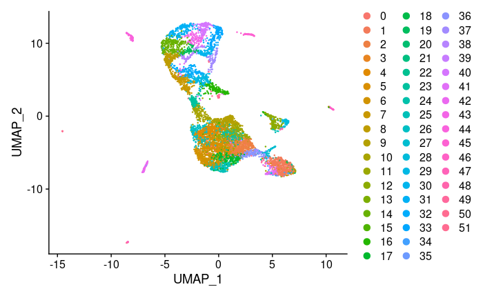

We don’t have any annotation for our clusters, so how about we use an already annotated dataset to find the annotations?

```r
anchors <- FindTransferAnchors(reference = ref, query = seur,
    dims = 1:20, reference.reduction = "pca", verbose = F, normalization.method = "SCT")
predictions <- TransferData(anchorset = anchors, refdata = ref@meta.data$simple_clusters,
    dims = 1:20, verbose = F)
# Save prediction
write.csv(predictions, "/mnt/Data1/public_vignettes/seurat_data/predictions_Nx1.csv")
names_col = colnames(predictions)
```

There are several columns in the prediction object. The column “predicted.id” is the column which contains the predicted cluster for each cell. The next n columns (n is the number of clusters in the reference) are each score of cluster for each cells. The last column, “prediction.score.max” represents the score associated with the predicted id in first column (and can be retrieve by taking the max of the n columns before).

```r
seur@meta.data[,names_col] <- predictions
```

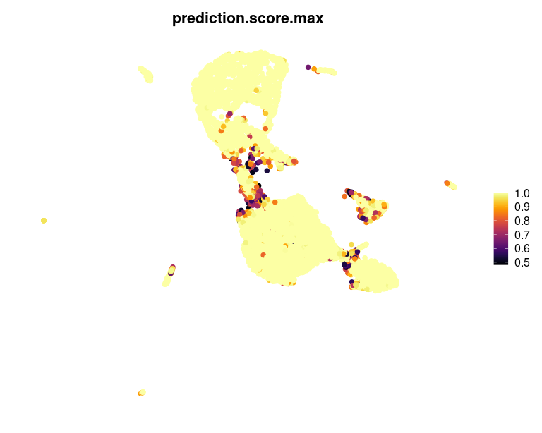

```r
FeaturePlot(seur, features = "prediction.score.max", pt.size = 2) + scale_colour_viridis(option = "B") + NoAxes()
```

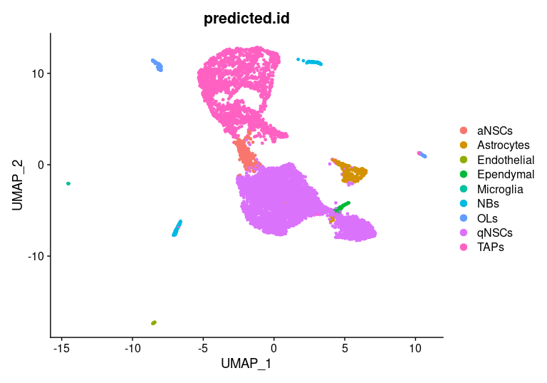

```r
DimPlot(seur, group.by = "predicted.id", pt.size = 1)
```

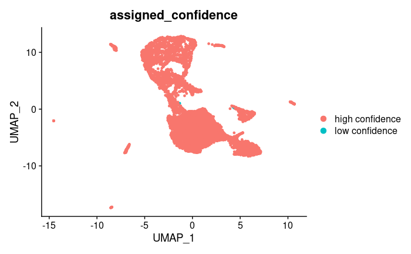

```r
seur@meta.data$assigned_confidence <- ifelse(seur@meta.data$prediction.score.max > 0.5, "high confidence", "low confidence")
DimPlot(seur, group.by = "assigned_confidence", pt.size = 1)
```

We assign low confidence prediction to cells which have a prediction score of less than 0.5, and high confidence score for cells having a score higher than 0.5.

We can also check for a specific cluster prediction score, for example the Astrocytes score :

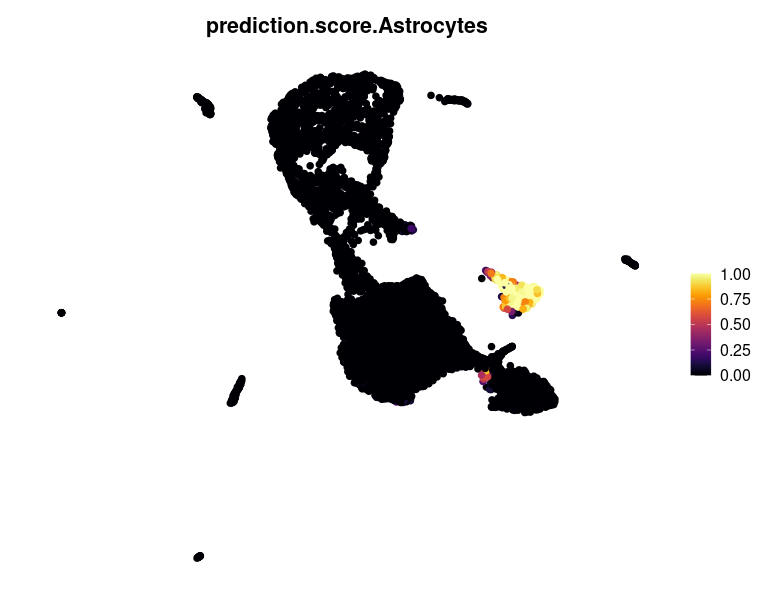

```r
FeaturePlot(seur, features = "prediction.score.Astrocytes", pt.size = 2) + scale_colour_viridis(option = "B") + NoAxes()
```

We can also check the number of cells per cluster (it is not only applicable to clusters from transfert, but for any column of the metadata with discrete values).

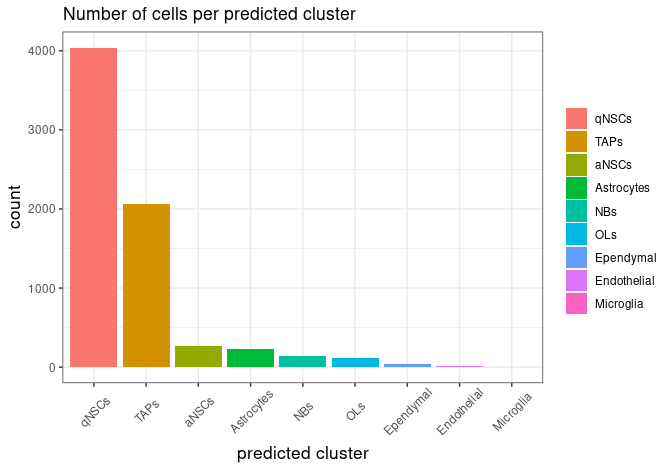

```r
clusters <- data.frame(clust = seur@meta.data$predicted.id, row.names = Cells(seur))
clusters_count <- count(clusters, clust)
clusters$clust <- factor(clusters$clust, levels = clusters_count$clust[order(clusters_count$n, decreasing = T)])
ggplot(clusters, aes(x = clust, fill = clust)) +
  geom_bar() +
  theme_bw() +
  xlab("predicted cluster") +
  ggtitle("Number of cells per predicted cluster") +
  theme(axis.text.x=element_text(angle = 45, vjust = 0.6),
        legend.title = element_blank(),
        axis.title = element_text(size = 13))
```

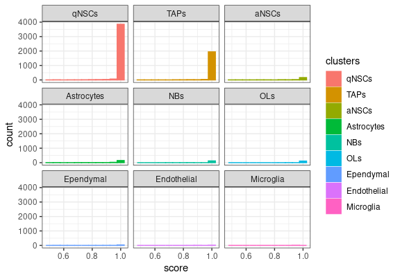

```r
clusters <- data.frame(clust = seur@meta.data$predicted.id, score = seur@meta.data$prediction.score.max, row.names = Cells(seur))
clusters_count <- count(clusters, clust)
clusters$clusters <- factor(clusters$clust, levels = clusters_count$clust[order(clusters_count$n, decreasing = T)])

ggplot(data = clusters, aes(x = score, colour = clusters, fill = clusters)) +
  geom_histogram(binwidth = 0.05) + facet_wrap(~clusters) + theme_bw()
```

This plot shows the score per cluster, for each cell predicted as this cluster. What we are expecting are profile of high number of cells with a high score (right part of each histogram). Profile which have a high number of cells with a low score (left of he histogram) are cells which Seurat have a hard time to predict the correct cluster. This can be caused for example by a cluster of cells which are not present in the reference, or cells that are so close to 2 clusters that the algorithm can’t can’t really decide which cluster to assign to the cells.

# Transfer UMAP and cell identities

To transfer the UMAP information, you need to have run the UMAP with the parameter `return.model = TRUE`. Otherwise Seurat will not be able to transfer. At the same time, the `MapQuery` function allows to transfer clusters (although returning a bit less information than the `TransferData` function). You can transfer as much cluster columns as you want from the reference, adding them in the list of `refdata`.

```r
anchors <- FindTransferAnchors(reference = ref, query = seur,
    dims = 1:20, reference.reduction = "pca", verbose = F, normalization.method = "SCT")
seur <- MapQuery(anchorset = anchors, reference = ref, query = seur,
    refdata = list(simple_clusters = "simple_clusters"), reference.reduction = "pca", reduction.model = "umap")
```

We can display our clusters on the predicted UMAP, or…

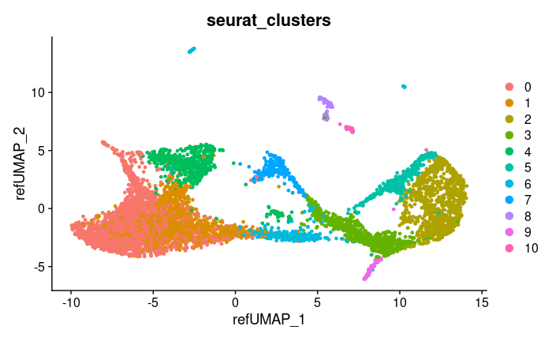

```r
DimPlot(seur, reduction = "ref.umap", pt.size = 1, group.by = "seurat_clusters")
```

… the predicted clusters on our UMAP.

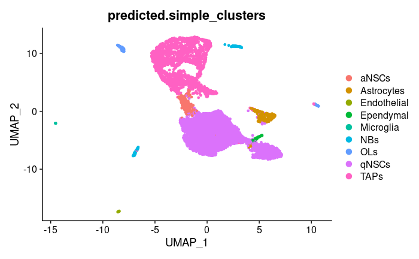

```r
DimPlot(seur, group.by = "predicted.simple_clusters", pt.size = 1, reduction = "umap")
```

We can also display the predicted clusters on the predicted UMAP.

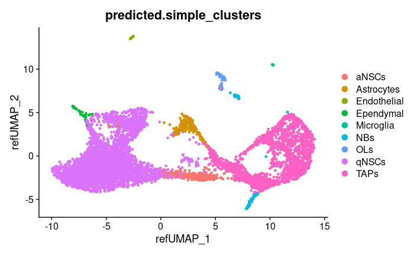

```r
DimPlot(seur, reduction = "ref.umap", pt.size = 1, group.by = "predicted.simple_clusters")
```

We can also do the same plots as with the `TransferData`, except for the score of a specific cluster.